# JIP45_HW3_INFSCI2160

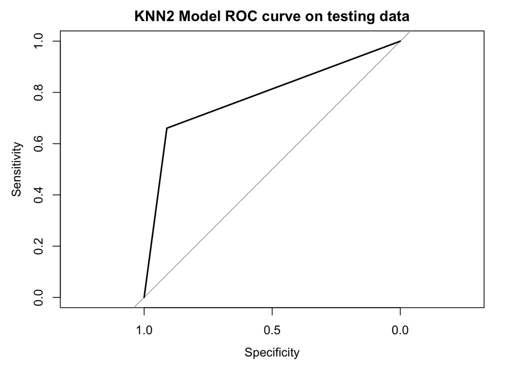

```r
# KNN in testing data
adult_knn2_roc_plot <- plot(adult_knn2_roc, main = "KNN2 Model ROC curve on testing data")
```

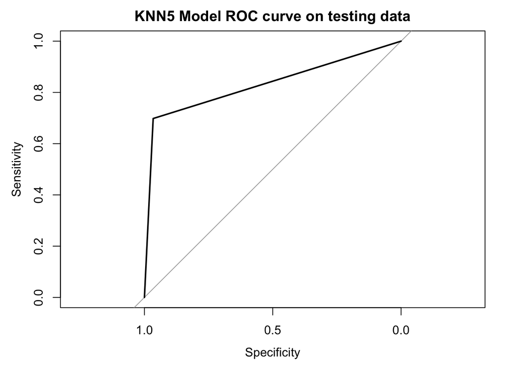

```r
adult_knn5_roc_plot <- plot(adult_knn5_roc, main = "KNN5 Model ROC curve on testing data")
```

[figure not shown]

```r
# ROC & AUC of KNN2
adult_knn2_train_roc <- roc(adult_train_pred$adult_train_tbl.Salary.norm, as.numeric(adult_train_pred$PRED_KNN2))
adult_knn2_train_auc <- auc(adult_knn2_train_roc)

# ROC & AUC of KNN5
adult_knn5_train_roc <- roc(adult_train_pred$adult_train_tbl.Salary.norm, as.numeric(adult_train_pred$PRED_KNN5))
adult_knn5_train_auc <- auc(adult_knn5_train_roc)

adult_knn2_train_roc_plot <- plot(adult_knn2_train_auc, main = "KNN2 Model ROC curve on training data")
```

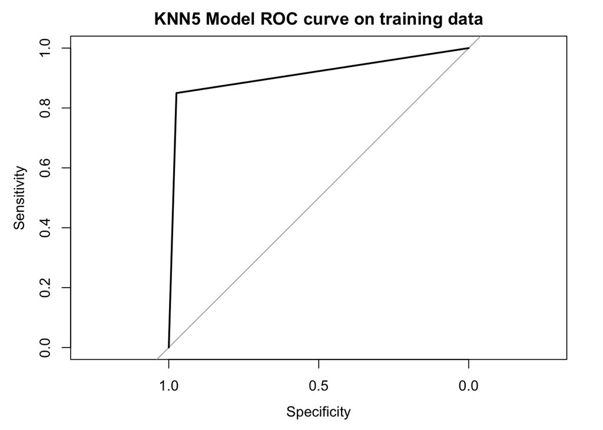

```r
adult_knn5_train_roc_plot <- plot(adult_knn5_train_roc, main = "KNN5 Model ROC curve on training data")
```

- Are you confident in your model? Why or why not?

Similar concepts as before, this model performs a reasonable ROC and AUC values in both training and testing dataset.

### Question #3

- Plot the ROC curves for both of your models.

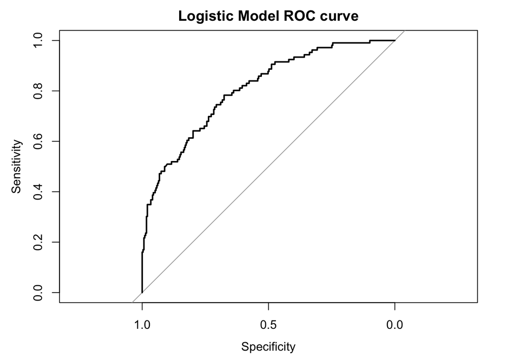

```r
# plot
adult_log_roc_plot <- plot(adult_log_roc, main = "Logistic Model ROC curve")
```

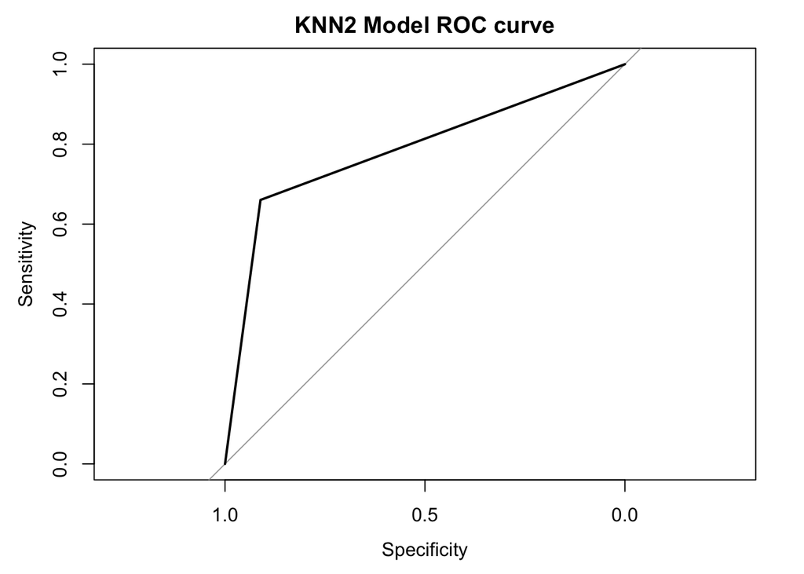

```r
adult_knn2_roc_plot <- plot(adult_knn2_roc, main = "KNN2 Model ROC curve")
```

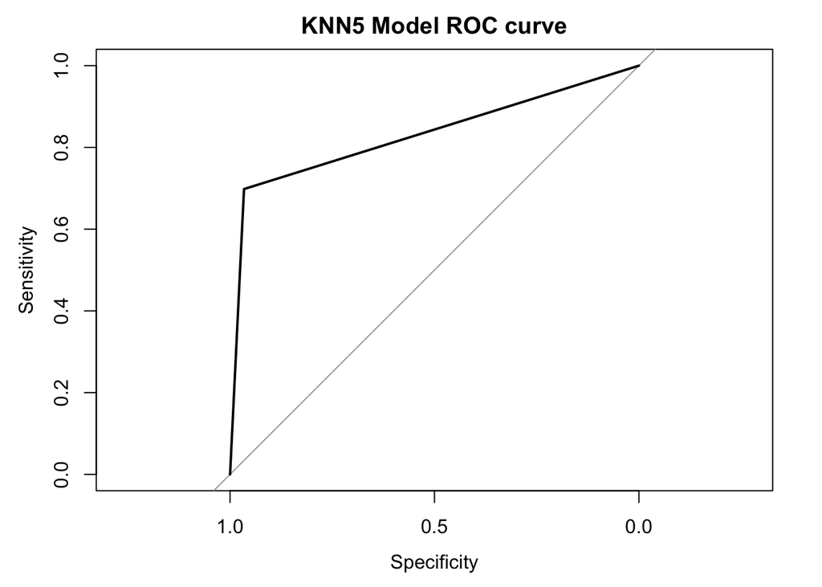

```r
adult_knn5_roc_plot <- plot(adult_knn5_roc, main = "KNN5 Model ROC curve")
```

- What is the AUC for your models? Which model performs better in terms of AUC?

```r
adult_log_auc
```

```
## Area under the curve: 0.8075
```

```r
ci.auc(adult_log_auc)
```

```
## 95% CI: 0.7599-0.8551 (DeLong)
```

```r
adult_knn2_auc
```

```
## Area under the curve: 0.7858
```

```r
ci.auc(adult_knn2_auc)
```

```
## 95% CI: 0.7377-0.834 (DeLong)
```

```r
adult_knn5_auc
```

```
## Area under the curve: 0.832
```

```r
ci.auc(adult_knn5_auc)
```

```
## 95% CI: 0.7869-0.8771 (DeLong)
```

### Question #4

##### Create a confusion matrix on your testing data to and answer the following questions:

- What is the accuracy of your models?
- What is the precision of your model?
- What is the negative predictive value of your model?
- What is the sensitivity of your model?
- What is the specificity of your model?
- What is the F-1 score of your model?

```r
# confusion matrix
true_salary <- adult_test_pred$Salary.norm
log_pred_salary <- adult_test_pred$P_RESP
knn2_pred_salary <- adult_test_pred$PRED_KNN2
knn5_pred_salary <- adult_test_pred$PRED_KNN5

log_conf_mat <- table(true_salary, log_pred_salary)
knn2_conf_mat <- table(true_salary, knn2_pred_salary)
knn5_conf_mat <- table(true_salary, knn5_pred_salary)

confusionMatrix(log_conf_mat, mode = "everything", positive="1")
```

```
## Confusion Matrix and Statistics
##
##            log_pred_salary
## true_salary   0   1
##           0 281  12
##           1  65  41
##
##                Accuracy : 0.807
##                  95% CI : (0.7648, 0.8446)
##     No Information Rate : 0.8672
##     P-Value [Acc > NIR] : 0.9997
##
##                   Kappa : 0.4115
##  Mcnemar's Test P-Value : 3.105e-09
##
##             Sensitivity : 0.7736
##             Specificity : 0.8121
##          Pos Pred Value : 0.3868
##          Neg Pred Value : 0.9590
##               Precision : 0.3868
##                  Recall : 0.7736
##                      F1 : 0.5157
##              Prevalence : 0.1328
##          Detection Rate : 0.1028
##    Detection Prevalence : 0.2657
##       Balanced Accuracy : 0.7929
##
##        'Positive' Class : 1
##
```

```r
confusionMatrix(knn2_conf_mat, mode = "everything", positive="1")
```

```
## Confusion Matrix and Statistics
##
##            knn2_pred_salary
## true_salary   0   1
##           0 267  26
##           1  36  70
##
##                Accuracy : 0.8446
##                  95% CI : (0.8053, 0.8787)
##     No Information Rate : 0.7594
##     P-Value [Acc > NIR] : 2.042e-05
##
##                   Kappa : 0.5894
##  Mcnemar's Test P-Value : 0.253
##
##             Sensitivity : 0.7292
##             Specificity : 0.8812
##          Pos Pred Value : 0.6604
##          Neg Pred Value : 0.9113
##               Precision : 0.6604
##                  Recall : 0.7292
##                      F1 : 0.6931
##              Prevalence : 0.2406
##          Detection Rate : 0.1754
##    Detection Prevalence : 0.2657
##       Balanced Accuracy : 0.8052
##
##        'Positive' Class : 1
##
```

```r
confusionMatrix(knn5_conf_mat, mode = "everything", positive="1")
```

```
## Confusion Matrix and Statistics
##
##            knn5_pred_salary
## true_salary   0   1
##           0 283  10
##           1  32  74
##
##                Accuracy : 0.8947
##                  95% CI : (0.8604, 0.9231)
##     No Information Rate : 0.7895
##     P-Value [Acc > NIR] : 1.974e-08
##
##                   Kappa : 0.7111
##  Mcnemar's Test P-Value : 0.001194
##
##             Sensitivity : 0.8810
##             Specificity : 0.8984
##          Pos Pred Value : 0.6981
##          Neg Pred Value : 0.9659
##               Precision : 0.6981
##                  Recall : 0.8810
##                      F1 : 0.7789
##              Prevalence : 0.2105
##          Detection Rate : 0.1855
##    Detection Prevalence : 0.2657
##       Balanced Accuracy : 0.8897
##
##        'Positive' Class : 1
##
```

### Question 5

- How did you choose your threshold for classification?

```r
# AUC at different thresholds based on our ROC plot
adult_log_thresholds <- data.frame(ci.thresholds(adult_log_roc))
print(adult_log_thresholds)
```

```
##                    specificity.2.5. specificity.50. specificity.97.5.
## 0.0277141719335575       0.06825939      0.09897611         0.1331058
## 0.0591852626499336       0.19795222      0.24573379         0.2935154
## 0.0602894912615163       0.20136519      0.24914676         0.2969283
## 0.0713516197698551       0.25597270      0.30716724         0.3583618
## 0.0752635233595966       0.27645051      0.32764505         0.3788396
## 0.0785000139092744       0.28668942      0.33788396         0.3924915
## 0.0839073159259922       0.30716724      0.35836177         0.4129693
## 0.093085805711969        0.34470990      0.39931741         0.4539249
## 0.0975554937233015       0.36518771      0.41979522         0.4744027
## 0.113282710088181        0.41638225      0.47440273         0.5324232
## 0.121317842761928        0.43003413      0.48805461         0.5460751
## 0.125398255577507        0.44027304      0.49829352         0.5529010
## 0.125967203855418        0.44368601      0.50170648         0.5597270
## 0.138844299284016        0.47431741      0.52901024         0.5837031
## 0.146233677679759        0.48122867      0.53924915         0.5938567
## 0.149717955272921        0.48464164      0.54266212         0.5972696
## 0.16975049545233         0.51877133      0.57679181         0.6313993
## 0.175459451792431        0.52901024      0.58703072         0.6416382
## 0.183884446348041        0.54607509      0.60409556         0.6587031
## 0.189188194772146        0.55972696      0.61433447         0.6689420
## 0.20141497072357         0.58361775      0.63822526         0.6928328
## 0.204318635200685        0.59044369      0.64505119         0.6996587
## 0.220007443318623        0.62116041      0.67576792         0.7303754
## 0.223800033660943        0.62798635      0.68259386         0.7372014
## 0.228098777265381        0.63481229      0.68941980         0.7406143
## 0.237650365241845        0.65187713      0.70648464         0.7576792
## 0.244302946740688        0.66211604      0.71331058         0.7645051
## 0.246241317227561        0.66552901      0.71672355         0.7679181
## 0.251265002532783        0.67576792      0.72696246         0.7781570
## 0.258161902196951        0.68600683      0.73720137         0.7850683
## 0.266718677321239        0.69283276      0.74402730         0.7918089
## 0.278607283060812        0.70639932      0.75426621         0.8020478
## 0.294614133051049        0.72013652      0.77133106         0.8191126
## 0.306507479308261        0.75085324      0.79863481         0.8430034
## 0.315554011646409        0.77133106      0.81569966         0.8600683
## 0.323228512416663        0.77815700      0.82252560         0.8668942
## 0.324998233971152        0.78148464      0.82593857         0.8703072
## 0.328377251901526        0.78498294      0.82935154         0.8737201
## 0.328598678869687        0.78839590      0.83276451         0.8771331
```

[output cut: 75 more lines]

```
## 0.440972654519559        0.34905660       0.4433962         0.5377358
## 0.445965587610297        0.33962264       0.4339623         0.5283019
## 0.456873260430046        0.33018868       0.4245283         0.5188679
## 0.46602239788954         0.32075472       0.4150943         0.5094340
## 0.475568692975876        0.31132075       0.4056604         0.5000000
## 0.486858845301542        0.30188679       0.3962264         0.4905660
## 0.50062359185579         0.29245283       0.3867925         0.4811321
## 0.512250797882546        0.27358491       0.3679245         0.4622642
## 0.555675120121672        0.25471698       0.3490566         0.4433962
## 0.601868658284773        0.21698113       0.3018868         0.3962264
## 0.671033777967038        0.16014151       0.2358491         0.3207547
## 0.679300777051174        0.15094340       0.2264151         0.3113208
## 0.684323608878679        0.14150943       0.2169811         0.3018868
## 0.789835734096853        0.10377358       0.1698113         0.2452830
## 0.850418097285343        0.09433962       0.1603774         0.2358491
```

```r
# new threshold increase our sensitivity and specificity

p_test_quantiles <- quantile(adult_test_pred$P_TEST, probs = seq(0, 1, 0.20), na.rm = FALSE, names = TRUE, type = 9)
p_test_quantiles
```

```
##          0%         20%         40%         60%         80%        100%
## 0.002616923 0.064322730 0.125950274 0.246421953 0.416435684 1.000000000
```

```r
adult_test_pred <- adult_test_tbl %>%
  mutate(P_TEST = predict(adult_log, newdata = adult_test_tbl, type = "response"),
         P_RESP = ifelse(P_TEST >= 0.5, 1, 0))

adult_test_pred <- adult_test_pred %>%
  mutate(prob_bins = ifelse(P_TEST <= 0.064322730 , "Bin 1",
                           ifelse(P_TEST > 0.064322730  & P_TEST <= 0.125950274, "Bin 2",
                                  ifelse(P_TEST > 0.125950274 & P_TEST <= 0.246421953 , "Bin 3",
                                         ifelse(P_TEST > 0.246421953 & P_TEST <= 0.416435684, "Bin 4",
                                                ifelse(P_TEST > 0.416435684, "Bin 5", "Max Bin"))))))

prob_bins <- adult_test_pred$prob_bins

table(true_salary, log_pred_salary, prob_bins)
```

```
## , , prob_bins = Bin 1
##
##            log_pred_salary
## true_salary  0  1
##           0 77  0
##           1  3  0
##
## , , prob_bins = Bin 2
##
##            log_pred_salary
## true_salary  0  1
##           0 70  0
##           1 10  0
##
## , , prob_bins = Bin 3
##
##            log_pred_salary
## true_salary  0  1
##           0 63  0
##           1 16  0
##
## , , prob_bins = Bin 4
##
##            log_pred_salary
## true_salary  0  1
##           0 56  0
##           1 24  0
##
## , , prob_bins = Bin 5
##
##            log_pred_salary
## true_salary  0  1
##           0 15 12
##           1 12 41
```

- Based on question 4, what are some good things about your model? What are some limitations of your model?

In this case, we are using two algorithms Logistic Regression and KNN to predict Salary of the Adult dataset. Because the feature of Salary is a binary feature that only contains two categories ( <=50K and >50K). The Logistic Regression model is really good at this kind of prediction range, and produce a range of values between 0 to 1 in order to fulfill the target. However, the KNN model performs better prediction than the Logistic Regression model. This indicates that the KNN model is more sensitive than Logistic Regression model in this prediction based on “Adult” dataset. But the KNN model has an obvious problem on feature types. It requires features are all numeric type. In the dataset, nearly half of features are categories. And if we convert them into numeric, this is not an absolutely accurate way to assign them.